# DeSeq2 analysis of Ssd1 enrichment compared to RNA-seq, on full-length transcripts

Edward Wallace

6th Feb 2021

# Summary

This script analyses relative *enrichment* of Ssd1 on mRNA, by processing time & condition matched RNA seq and Ssd1 CRAC data. We use the DeSeq2 package for differential expression analysis, here to analyse differential enrichment of Ssd1-bound transcripts. We report enriched genes for each analysis, using as cutoff 2x enrichment (log2-fold change of 1) with an adjusted p-value 0.05 (5% FDR).

Output files

- `results/Ssd1_enrichment_DeSeq2_30C.txt`
- `results/Ssd1_enrichment_DeSeq2_42C.txt`
- `results/Ssd1_enrichment_DeSeq2_30C_2x_padj0p05_genesonly.txt`
- `results/Ssd1_enrichment_DeSeq2_42C_2x_padj0p05_genesonly.txt`
- `figure_out/deseq2_Ssd1_CRAC_enrichment_suppfigure.png` - supplementary figure

This script relies on CRAC transcript counts produced by `multiBamCov` running in the CRAC pipeline, and found in `Ssd1_CRAC_demult_dedup_20190114_all/multicov_analyses/allsample_transcriptcounts.txt`. So it must be run after `src/CRAC_pipeline_SE_demult_dedup.py`, see the repository `README.md` for details.

This script also relies on RNA-seq transcript counts produced by `multiBamCov` running `process_RNAseq.Rmd`, found in `results/RNAseq_stressmatched_transcriptcounts.txt`. It must be run after `process_RNAseq.Rmd`.

# Testing RNA-seq count data alone

## Load RNA-seq count data

```r
counts_RNA_stranded <- readr::read_tsv("../results/RNAseq_stressmatched_transcriptcounts.txt",
                                comment = "#")  %>%
  dplyr::mutate(Gene=gene_from_attr(attributes))
```

## Test DeSeq2 on RNA-seq data, 30C vs 42C

Setup and run DeSeq2 analysis on heat-shock data for RNA alone, to confirm we can recover the expected heat shock response.

```r
sampledata_RNAheat <-
  data.frame(
    sample = c("RNA_A_30","RNA_B_30","RNA_E_42","RNA_F_42"),
    temperature = c("30","30","42","42"),
    batch = c("A","B","A","B")) %>%
  magrittr::set_rownames(.$sample)

counts_RNAheat <-
  dplyr::select(counts_RNA_stranded, sampledata_RNAheat$sample) %>%
  magrittr::set_rownames(counts_RNA_stranded$Gene)

dds_RNAheat <- DESeqDataSetFromMatrix(countData = counts_RNAheat,
                              colData = sampledata_RNAheat,
                              design = ~ temperature) %>%
  DESeq()

resultsNames(dds_RNAheat)
```

```
## [1] "Intercept"            "temperature_42_vs_30"
```

```r
results_RNAheat <- results(dds_RNAheat, name="temperature_42_vs_30")

results_RNAheat
```

```
## log2 fold change (MLE): temperature 42 vs 30
## Wald test p-value: temperature 42 vs 30
## DataFrame with 5090 rows and 6 columns
##          baseMean log2FoldChange     lfcSE      stat       pvalue         padj
##         <numeric>      <numeric> <numeric> <numeric>    <numeric>    <numeric>
## YAL001C   3711.05      0.4817378 0.0902163  5.339811  9.30436e-08  1.51654e-07
## YAL002W   2019.69     -0.0124474 0.1173706 -0.106052  9.15541e-01  9.24629e-01
## YAL003W  68109.37      0.7955119 0.1071673  7.423086  1.14423e-13  2.30979e-13
## YAL005C 382632.94      3.6292959 0.1126486 32.217852 9.92593e-228 3.74024e-226
## YAL007C   3629.41     -0.7532234 0.0871795 -8.639910  5.62574e-18  1.31096e-17
## ...           ...            ...       ...       ...          ...          ...
## YPR198W  2166.023      -0.496006  0.114745  -4.32268  1.54148e-05  2.29351e-05
## YPR199C  1567.610       0.811329  0.104425   7.76950  7.87939e-15  1.65699e-14
## YPR200C   223.732       0.323000  0.201369   1.60402  1.08710e-01  1.24945e-01
## YPR201W   251.580       1.140186  0.178489   6.38799  1.68084e-10  3.06029e-10
## YPR204W  3291.233       0.204830  0.085741   2.38894  1.68971e-02  2.08024e-02
```

### Plot log2-fold-change

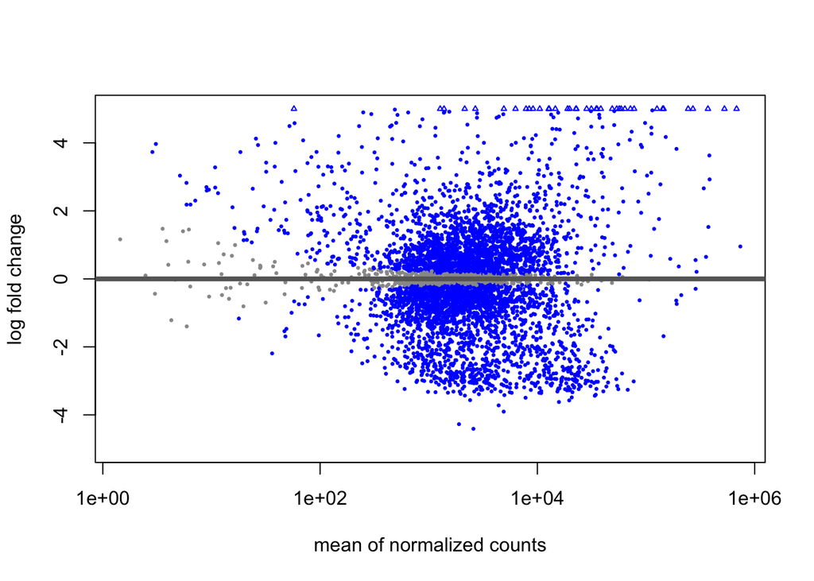

```r
plotMA(results_RNAheat, ylim=c(-5,5))
```

### Estimate and plot log2-fold-change with shrinkage estimator

```r
results_RNAheatLFC <- lfcShrink(dds_RNAheat, coef="temperature_42_vs_30", type="apeglm")

results_RNAheatLFC
```

```
## log2 fold change (MAP): temperature 42 vs 30
## Wald test p-value: temperature 42 vs 30
## DataFrame with 5090 rows and 5 columns
##          baseMean log2FoldChange     lfcSE       pvalue         padj
##         <numeric>      <numeric> <numeric>    <numeric>    <numeric>
## YAL001C   3711.05      0.4786390 0.0899706  9.30436e-08  1.51654e-07
## YAL002W   2019.69     -0.0121368 0.1165992  9.15541e-01  9.24629e-01
## YAL003W  68109.37      0.7828443 0.1069571  1.14423e-13  2.30979e-13
## YAL005C 382632.94      3.6332463 0.1125737 9.92593e-228 3.74024e-226
## YAL007C   3629.41     -0.7487983 0.0870308  5.62574e-18  1.31096e-17
## ...           ...            ...       ...          ...          ...
## YPR198W  2166.023      -0.490505 0.1142344  1.54148e-05  2.29351e-05
## YPR199C  1567.610       0.805041 0.1042170  7.87939e-15  1.65699e-14
## YPR200C   223.732       0.311725 0.1979804  1.08710e-01  1.24945e-01
## YPR201W   251.580       1.119046 0.1780971  1.68084e-10  3.06029e-10
## YPR204W  3291.233       0.203553 0.0854502  1.68971e-02  2.08024e-02
```

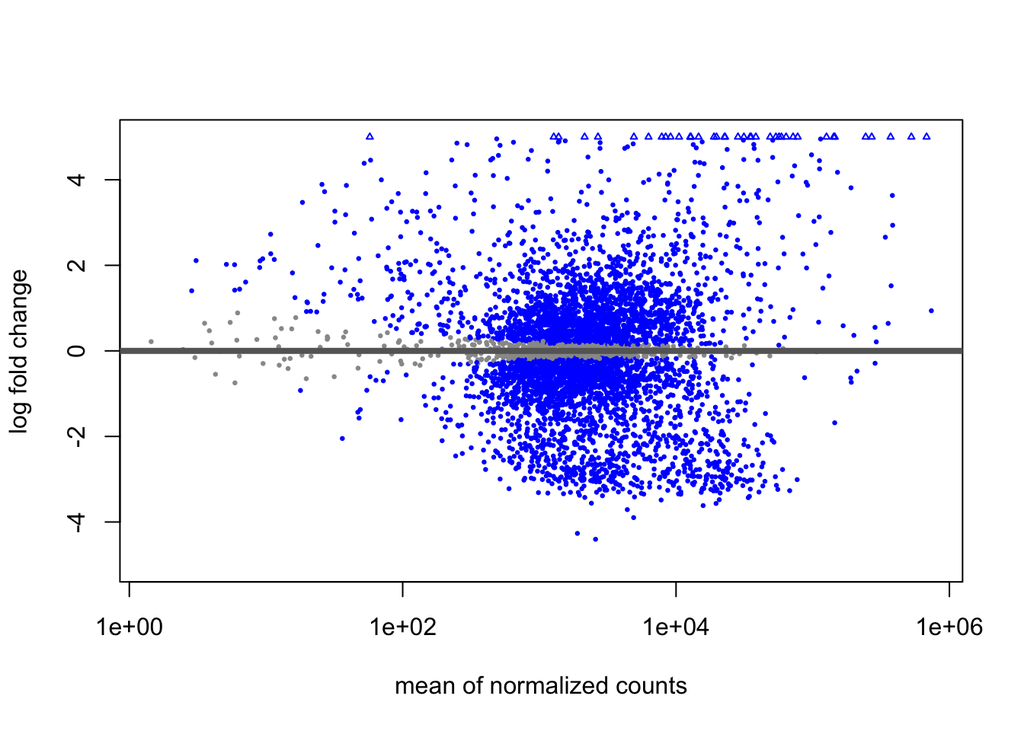

```r
plotMA(results_RNAheatLFC, ylim=c(-5,5))
```

This shrinkage makes little difference.

# Testing Ssd1-bound data alone

## Load Ssd1-bound genewise counts

```r
counts_Ssd1_stranded <- readr::read_tsv("../Ssd1_CRAC_demult_dedup_20190114_all/multicov_analyses/allsample_transcriptcounts.txt",
                                 comment = "#") %>%
  dplyr::mutate(Gene=gene_from_attr(attributes))%>%
  dplyr::select(Gene,seqname,feature,start,end,attributes,
         Ssd1_3_30 = `20190114_Ssd1_CRAC_trimmed_NNNGTGAGC_SSD1_3_30.bam`,
         Ssd1_4_30 = `20190114_Ssd1_CRAC_trimmed_NNNTGGAGC_SSD1_4_30.bam`,
         Ssd1_3_42 = `20190114_Ssd1_CRAC_trimmed_NNNAGAGC_SSD1_3_42.bam`,
         Ssd1_4_42 = `20190114_Ssd1_CRAC_trimmed_NNNCTAGC_SSD1_4_42.bam`,
         BY4741 = `20190114_Ssd1_CRAC_trimmed_NNNGACTTAGC_BY4741.bam`)
```

```r
counts_Ssd1_stranded
```

```
## # A tibble: 5,090 x 11
##    Gene  seqname feature  start    end attributes Ssd1_3_30 Ssd1_4_30 Ssd1_3_42
##    <chr> <chr>   <chr>    <dbl>  <dbl> <chr>          <dbl>     <dbl>     <dbl>
##  1 YAL0… chrI    primar… 147469 151191 ID=YAL001…        25         0        49
##  2 YAL0… chrI    primar… 143682 147656 ID=YAL002…        16        15        10
##  3 YAL0… chrI    primar… 142153 143381 ypd=4653;…       410       183       302
##  4 YAL0… chrI    primar… 139357 141493 ypd=236;I…       273       115      1961
##  5 YAL0… chrI    primar… 137552 138414 ypd=203;I…        17         9         1
##  6 YAL0… chrI    primar… 136866 137637 ypd=146;I…         0         0        19
##  7 YAL0… chrI    primar… 135823 136756 ypd=6;ID=…         4         0         5
##  8 YAL0… chrI    primar… 134025 135699 ypd=2;ID=…         8         4         9
##  9 YAL0… chrI    primar… 132195 134173 ypd=3;ID=…         1         9         0
## 10 YAL0… chrI    primar… 130735 132082 ypd=667;I…        39        42        59
## # … with 5,080 more rows, and 2 more variables: Ssd1_4_42 <dbl>, BY4741 <dbl>
```

```r
sampledata_Ssd1heat <-
  data.frame(
    sample = c("Ssd1_3_30","Ssd1_4_30","Ssd1_3_42","Ssd1_4_42"),
    temperature = c("30","30","42","42"),
    batch = c("3","4","3","4")) %>%
  magrittr::set_rownames(.$sample)

counts_Ssd1heat <-
  dplyr::select(counts_Ssd1_stranded, sampledata_Ssd1heat$sample) %>%
  magrittr::set_rownames(counts_Ssd1_stranded$Gene)

dds_Ssd1heat <- DESeqDataSetFromMatrix(countData = counts_Ssd1heat,
                              colData = sampledata_Ssd1heat,
                              design = ~ temperature) %>%
  DESeq()

resultsNames(dds_Ssd1heat)
```

```
## [1] "Intercept"            "temperature_42_vs_30"
```

```r
results_Ssd1heat <- results(dds_Ssd1heat, name="temperature_42_vs_30")

results_Ssd1heat
```

```
## log2 fold change (MLE): temperature 42 vs 30
## Wald test p-value: temperature 42 vs 30
## DataFrame with 5090 rows and 6 columns
##           baseMean log2FoldChange     lfcSE      stat      pvalue        padj
##          <numeric>      <numeric> <numeric> <numeric>   <numeric>   <numeric>
## YAL001C   22.19137      1.3587515  1.532317  0.886730 3.75224e-01 7.88208e-01
## YAL002W   13.77098     -1.1880073  1.448492 -0.820168 4.12120e-01 8.13595e-01
## YAL003W  334.14894     -0.0373425  0.427343 -0.087383 9.30367e-01 9.89074e-01
## YAL005C 1159.20096      3.2475428  0.359650  9.029726 1.72101e-19 3.36003e-17
## YAL007C    9.12018     -2.2084020  1.824938 -1.210125 2.26231e-01 6.41832e-01
## ...            ...            ...       ...       ...         ...         ...
## YPR198W   6.642221      1.4742516   2.47845  0.594829    0.551958    0.888002
## YPR199C   7.186730      1.3681224   2.24529  0.609329    0.542307    0.883557
## YPR200C   0.119135      0.5339813   4.96947  0.107452    0.914430          NA
## YPR201W   1.862892      2.0984925   3.98059  0.527181    0.598068          NA
## YPR204W  10.037615     -0.0380722   1.70743 -0.022298    0.982210    0.996972
```

### Plot log2-fold-change

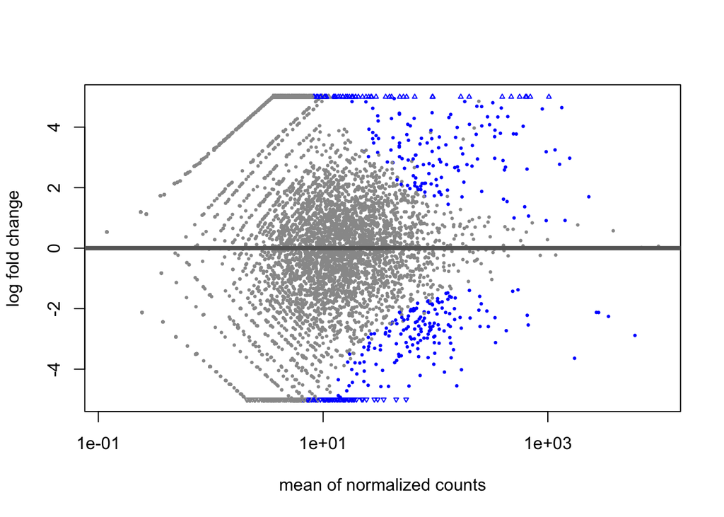

```r
plotMA(results_Ssd1heat, ylim=c(-5,5))
```

### Estimate and plot log2-fold-change with shrinkage estimator

```r
results_Ssd1heatLFC <- lfcShrink(dds_Ssd1heat, coef="temperature_42_vs_30", type="apeglm")

results_Ssd1heatLFC
```

```
## log2 fold change (MAP): temperature 42 vs 30
## Wald test p-value: temperature 42 vs 30
## DataFrame with 5090 rows and 5 columns
##           baseMean log2FoldChange     lfcSE      pvalue        padj
##          <numeric>      <numeric> <numeric>   <numeric>   <numeric>
## YAL001C   22.19137       0.441369  0.943364 3.75224e-01 7.88208e-01
## YAL002W   13.77098      -0.405354  0.909147 4.12120e-01 8.13595e-01
## YAL003W  334.14894      -0.030329  0.393948 9.30367e-01 9.89074e-01
## YAL005C 1159.20096       3.181226  0.361856 1.72101e-19 3.36003e-17
## YAL007C    9.12018      -0.554113  1.077496 2.26231e-01 6.41832e-01
## ...            ...            ...       ...         ...         ...
## YPR198W   6.642221     0.21306735  0.979303    0.551958    0.888002
## YPR199C   7.186730     0.23649914  0.968681    0.542307    0.883557
## YPR200C   0.119135     0.07285481  1.013106    0.914430          NA
## YPR201W   1.862892     0.11700427  1.004686    0.598068          NA
## YPR204W  10.037615    -0.00729589  0.875051    0.982210    0.996972
```

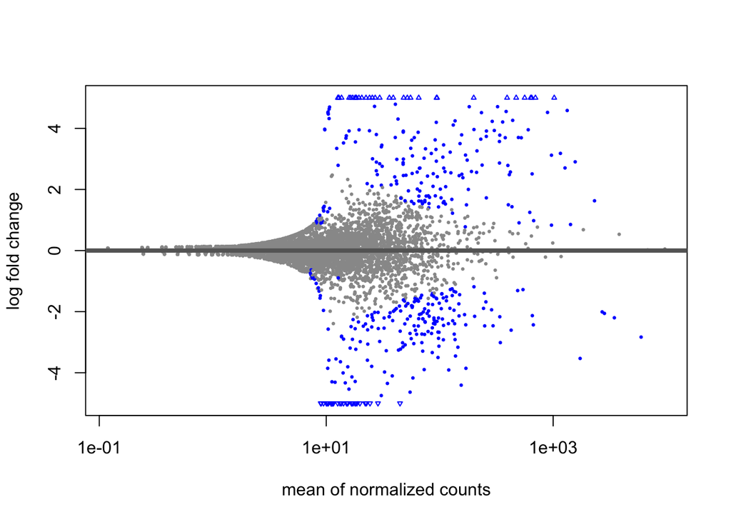

```r
plotMA(results_Ssd1heatLFC, ylim=c(-5,5))
```

This makes a big difference for low-detected transcripts here, because the depth of (deduplicated) sequence counts is low.

# Comparing Ssd1 CRAC to RNA-seq data to estimate enrichment in Ssd1-bound transcripts

This is the key part of the script in terms of new results.

## Setup enrichment in Ssd1-bound RNA

```r
# Describe samples for DESeq2
sampledata_Ssd1bind <-
  data.frame(
    sample = c("RNA_A_30","RNA_B_30","RNA_E_42","RNA_F_42",
               "Ssd1_3_30","Ssd1_4_30","Ssd1_3_42","Ssd1_4_42"),
    temperature = rep(c("30","30","42","42"),2),
    batch = c("A","B","A","B", "3","4","3","4"),
    type = rep(c("RNA","Ssd1"),each=4)
    ) %>%
  magrittr::set_rownames(.$sample)

# Split into two data frames to describe samples separately at each temperature
sampledata_Ssd1bind30 <- dplyr::filter(sampledata_Ssd1bind, temperature == "30")
sampledata_Ssd1bind42 <- dplyr::filter(sampledata_Ssd1bind, temperature == "42")

# Check that the Gene lists in two datasets are the same, throw and error if not
stopifnot(all.equal(counts_RNA_stranded$Gene, counts_Ssd1_stranded$Gene))

# Create DESeq2-format count data frame for 30C comparison
counts_Ssd1bind30 <- cbind(
  dplyr::select(counts_RNA_stranded, c("RNA_A_30","RNA_B_30")),
  dplyr::select(counts_Ssd1_stranded, c("Ssd1_3_30","Ssd1_4_30"))) %>%
  magrittr::set_rownames(counts_RNA_stranded$Gene)

# Create DESeq2-format count data frame for 42C comparison
counts_Ssd1bind42 <- cbind(
  dplyr::select(counts_RNA_stranded, c("RNA_E_42","RNA_F_42")),
  dplyr::select(counts_Ssd1_stranded, c("Ssd1_3_42","Ssd1_4_42"))) %>%
  magrittr::set_rownames(counts_RNA_stranded$Gene)
```

## Calculate enrichment in Ssd1-bound RNA at 30C

Here we run DESeq2 on the collected data to make the comparison between Ssd1-bound transcripts and total mRNA, only at 30C.

```r
# Run DESeq2
dds_Ssd1bind30 <- DESeqDataSetFromMatrix(countData = counts_Ssd1bind30,
                              colData = sampledata_Ssd1bind30,
                              design = ~ type) %>%
  DESeq()

# Check that we made the correct comparison
resultsNames(dds_Ssd1bind30)
```

```
## [1] "Intercept"        "type_Ssd1_vs_RNA"
```

```r
# Filter differentially bound genes with 2-fold change, adjusted p-value below 0.05
results_Ssd1bind30 <- results(dds_Ssd1bind30, name="type_Ssd1_vs_RNA",
                              lfcThreshold=1,alpha=0.05)

results_Ssd1bind30
```

```
## log2 fold change (MLE): type Ssd1 vs RNA
## Wald test p-value: type Ssd1 vs RNA
## DataFrame with 5090 rows and 6 columns
##          baseMean log2FoldChange     lfcSE      stat    pvalue      padj
##         <numeric>      <numeric> <numeric> <numeric> <numeric> <numeric>
## YAL001C   196.684      -0.261376  2.105546         0         1         1
## YAL002W   208.389       0.923820  0.304658         0         1         1
## YAL003W  4177.661       0.505666  0.264090         0         1         1
## YAL005C  3581.056      -0.312593  0.298851         0         1         1
## YAL007C   267.428      -0.508217  0.309355         0         1         1
## ...           ...            ...       ...       ...       ...       ...
## YPR198W 113.01677      -1.736819  1.424202 -0.517356  0.604908         1
## YPR199C  68.05478      -0.413775  1.635153  0.000000  1.000000         1
## YPR200C   6.90729      -2.098944  2.208282 -0.497646  0.618733         1
## YPR201W  10.85685      -0.313638  1.530231  0.000000  1.000000         1
## YPR204W 179.41106      -0.475253  0.704117  0.000000  1.000000         1
```

```r
summary(results_Ssd1bind30)
```

```
##
## out of 5087 with nonzero total read count
## adjusted p-value < 0.05
## LFC > 1.00 (up)    : 189, 3.7%
## LFC < -1.00 (down) : 111, 2.2%
## outliers [1]       : 0, 0%
## low counts [2]     : 0, 0%
## (mean count < 0)
## [1] see 'cooksCutoff' argument of ?results
## [2] see 'independentFiltering' argument of ?results
```

### Plot log2-fold-change

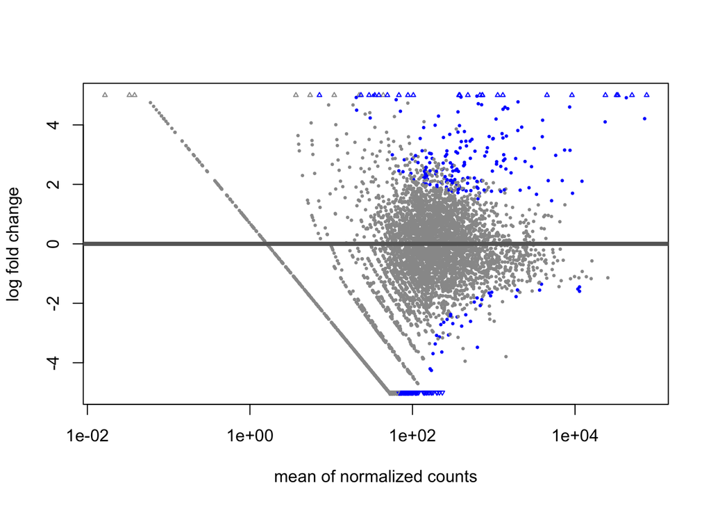

```r
plotMA(results_Ssd1bind30, ylim=c(-5,5))
```

### Estimate and plot log2-fold-change with shrinkage estimator

```r
results_Ssd1bind30LFC <- lfcShrink(dds_Ssd1bind30, coef="type_Ssd1_vs_RNA", type="apeglm",
                              lfcThreshold=1)

results_Ssd1bind30LFC
```

```
## log2 fold change (MAP): type Ssd1 vs RNA
##
## DataFrame with 5090 rows and 4 columns
##          baseMean log2FoldChange     lfcSE    svalue
##         <numeric>      <numeric> <numeric> <numeric>
## YAL001C   196.684     -0.0437485  0.917911  0.492629
## YAL002W   208.389      0.8665257  0.303723  0.262250
## YAL003W  4177.661      0.4877582  0.257726  0.581422
## YAL005C  3581.056     -0.2906617  0.287842  0.596096
## YAL007C   267.428     -0.4695443  0.296626  0.572793
## ...           ...            ...       ...       ...
## YPR198W 113.01677     -0.6555819  1.002604  0.240476
## YPR199C  68.05478     -0.1139306  0.869089  0.483849
## YPR200C   6.90729     -0.4274182  1.064987  0.289831
## YPR201W  10.85685     -0.0927666  0.851802  0.503143
## YPR204W 179.41106     -0.3277598  0.589115  0.523476
```

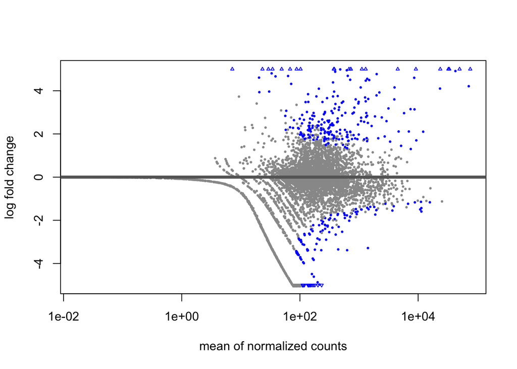

```r
plotMA(results_Ssd1bind30LFC, ylim=c(-5,5))
```

This makes a difference for low-detected transcripts here.

### Print estimates of log2 fold-change

Write the output to a file that will be saved and used for future analysis.

```r
tresults_Ssd1bind30 <- biobroom::tidy.DESeqResults(results_Ssd1bind30)

tresultsfile_30 <- "../results/Ssd1_enrichment_DeSeq2_30C.txt"

readr::write_lines(c("# Ssd1_enrichment_DeSeq2_30C.txt",
                     "# Analysis of Ssd1 enrichment at 30C, output from deseq2_Ssd1_CRAC_vs_RNAseq.Rmd",
                     "# This table is the result of biobroom::tidy applied to DeSeq2 results, then ordered by descending log2-fold change",
                     "# Edward.Wallace@ed.ac.uk, 6 Feb 2021",
                     "# "),
                   tresultsfile_30)

tresults_Ssd1bind30 %>%
  dplyr::arrange(desc(estimate)) %>%
  readr::write_tsv(tresultsfile_30, col_names = TRUE, append = TRUE)

enriched_Ssd1bind30 <-
  dplyr::filter(tresults_Ssd1bind30, estimate > 1, p.adjusted < 0.05) %>%
  dplyr::arrange(desc(estimate))

enriched_Ssd1bind30
```

```
## # A tibble: 189 x 7
##    gene      baseMean estimate stderror statistic  p.value p.adjusted
##    <chr>        <dbl>    <dbl>    <dbl>     <dbl>    <dbl>      <dbl>
##  1 YLR308W      23.2     10.9    1.99        4.95 7.57e- 7   3.30e- 5
##  2 YKR041W    9166.      10.3    0.0880    105.   0.         0.
##  3 YHR079C-A    68.1      9.20   0.761      10.8  4.55e-27   5.03e-25
##  4 YNL066W   76122.       8.22   0.0404    179.   0.         0.
##  5 YLR081W     374.       8.07   0.341      20.7  3.06e-95   7.42e-93
##  6 YLR013W       7.17     7.30   1.95        3.23 1.25e- 3   2.75e- 2
##  7 YBL043W     382.       7.27   0.309      20.3  2.78e-91   6.44e-89
##  8 YJL116C    1295.       6.98   0.135      44.2  0.         0.
##  9 YNR072W      34.4      6.47   0.902       6.06 1.37e- 9   7.74e- 8
## 10 YIL123W   33659.       6.44   0.139      39.2  0.         0.
## # … with 179 more rows
```

```r
readr::write_lines(enriched_Ssd1bind30$gene,
                   "../results/Ssd1_enrichment_DeSeq2_30C_2x_padj0p05_genesonly.txt")

depleted_Ssd1bind30 <-
  dplyr::filter(tresults_Ssd1bind30, estimate < -1, p.adjusted < 0.05) %>%
  dplyr::arrange(estimate)

depleted_Ssd1bind30
```

```
## # A tibble: 111 x 7
##    gene    baseMean estimate stderror statistic   p.value p.adjusted
##    <chr>      <dbl>    <dbl>    <dbl>     <dbl>     <dbl>      <dbl>
##  1 YER031C     202.    -6.97     1.45     -4.11 0.0000396    0.00139
##  2 YOR197W     179.    -6.79     1.45     -3.98 0.0000675    0.00230
##  3 YGR200C     170.    -6.72     1.45     -3.93 0.0000840    0.00281
##  4 YHR005C     160.    -6.63     1.46     -3.86 0.000112     0.00368
##  5 YML115C     151.    -6.55     1.46     -3.82 0.000136     0.00437
##  6 YFR004W     148.    -6.52     1.46     -3.79 0.000152     0.00485
##  7 YPL146C     142.    -6.46     1.46     -3.75 0.000177     0.00548
##  8 YBR041W     141.    -6.45     1.46     -3.74 0.000183     0.00557
##  9 YML130C     140.    -6.44     1.46     -3.74 0.000185     0.00559
## 10 YOR246C     137.    -6.41     1.46     -3.71 0.000206     0.00612
## # … with 101 more rows
```

### Make Volcano plot

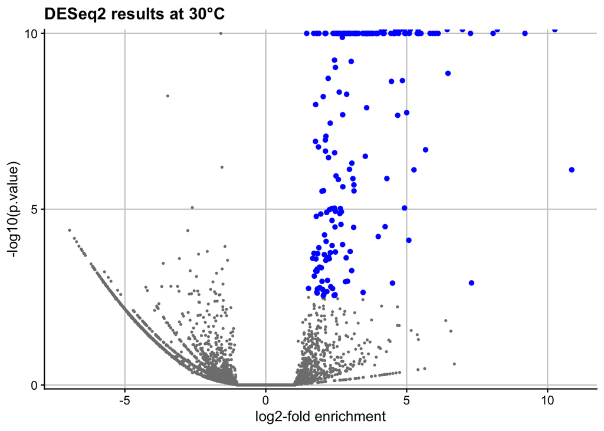

```r
volcano_30C <-
  ggplot(data = tresults_Ssd1bind30,
         aes(x=estimate,y=-log10(p.value))) +
  geom_point(colour = "grey50",size = 0.5) +
  geom_point(data = enriched_Ssd1bind30,
             colour = "blue") +
  scale_y_continuous(breaks = c(0,5,10),
                     limits = c(0,10),
                     expand = c(0.01,0.01),
                     oob = scales::squish) +
  labs(x = "log2-fold enrichment",
       title = "DESeq2 results at 30°C")

volcano_30C
```

## Calculate enrichment in Ssd1-bound RNA at 42C

Here we run DESeq2 again as above, but only comparing the data at 42C.

```r
dds_Ssd1bind42 <- DESeqDataSetFromMatrix(countData = counts_Ssd1bind42,
                              colData = sampledata_Ssd1bind42,
                              design = ~ type) %>%
  DESeq()

resultsNames(dds_Ssd1bind42)
```

```
## [1] "Intercept"        "type_Ssd1_vs_RNA"
```

```r
results_Ssd1bind42 <- results(dds_Ssd1bind42, name="type_Ssd1_vs_RNA",
                              lfcThreshold=1,alpha=0.05)

results_Ssd1bind42
```

```
## log2 fold change (MLE): type Ssd1 vs RNA
## Wald test p-value: type Ssd1 vs RNA
## DataFrame with 5090 rows and 6 columns
##          baseMean log2FoldChange     lfcSE      stat    pvalue      padj
##         <numeric>      <numeric> <numeric> <numeric> <numeric> <numeric>
## YAL001C   380.972       0.550654  0.877756    0.0000  1.000000         1
## YAL002W   131.370      -0.325796  0.516834    0.0000  1.000000         1
## YAL003W  5412.655      -0.375281  0.159367    0.0000  1.000000         1
## YAL005C 40019.050      -0.744051  0.148318    0.0000  1.000000         1
## YAL007C   118.367      -1.899249  0.769641   -1.1684  0.242645         1
## ...           ...            ...       ...       ...       ...       ...
## YPR198W  133.3994      0.0976389  1.681258   0.00000  1.000000         1
## YPR199C  144.8031      0.0078249  0.923490   0.00000  1.000000         1
## YPR200C   10.5118     -1.8697096  1.679332  -0.51789  0.604535        NA
## YPR201W   33.5374      0.8861321  0.742639   0.00000  1.000000         1
## YPR204W  195.9305     -0.9060286  0.444584   0.00000  1.000000         1
```

```r
summary(results_Ssd1bind42)
```

```
##
## out of 5088 with nonzero total read count
## adjusted p-value < 0.05
## LFC > 1.00 (up)    : 139, 2.7%
## LFC < -1.00 (down) : 77, 1.5%
## outliers [1]       : 0, 0%
## low counts [2]     : 198, 3.9%
## (mean count < 11)
## [1] see 'cooksCutoff' argument of ?results
## [2] see 'independentFiltering' argument of ?results
```

### Plot log2-fold-change

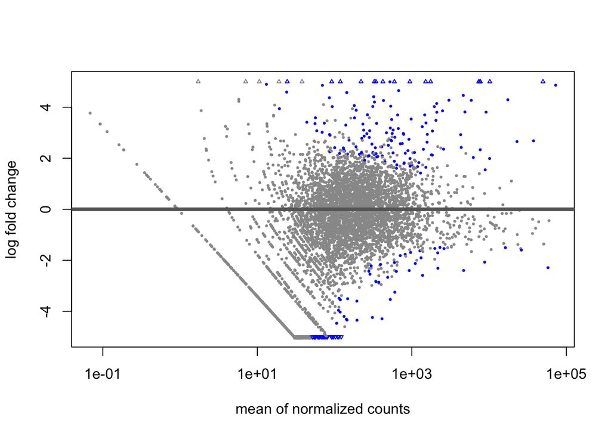

```r
plotMA(results_Ssd1bind42, ylim=c(-5,5))
```

### Estimate and plot log2-fold-change with shrinkage estimator

```r
results_Ssd1bind42LFC <- lfcShrink(dds_Ssd1bind42, coef="type_Ssd1_vs_RNA", type="apeglm",
                              lfcThreshold=1)

results_Ssd1bind42LFC
```

```
## log2 fold change (MAP): type Ssd1 vs RNA
##
## DataFrame with 5090 rows and 4 columns
##          baseMean log2FoldChange     lfcSE    svalue
##         <numeric>      <numeric> <numeric> <numeric>
## YAL001C   380.972       0.288936  0.651516 0.5156427
## YAL002W   131.370      -0.244773  0.455333 0.6120409
## YAL003W  5412.655      -0.358260  0.157249 0.6681964
## YAL005C 40019.050      -0.700810  0.147474 0.6327146
## YAL007C   118.367      -1.452831  0.765273 0.0876625
## ...           ...            ...       ...       ...
## YPR198W  133.3994      0.0258503  0.789067  0.562298
## YPR199C  144.8031      0.0069447  0.644671  0.601266
## YPR200C   10.5118     -0.5029552  0.908296  0.335663
## YPR201W   33.5374      0.5627195  0.635324  0.377255
## YPR204W  195.9305     -0.7624853  0.427867  0.336610
```

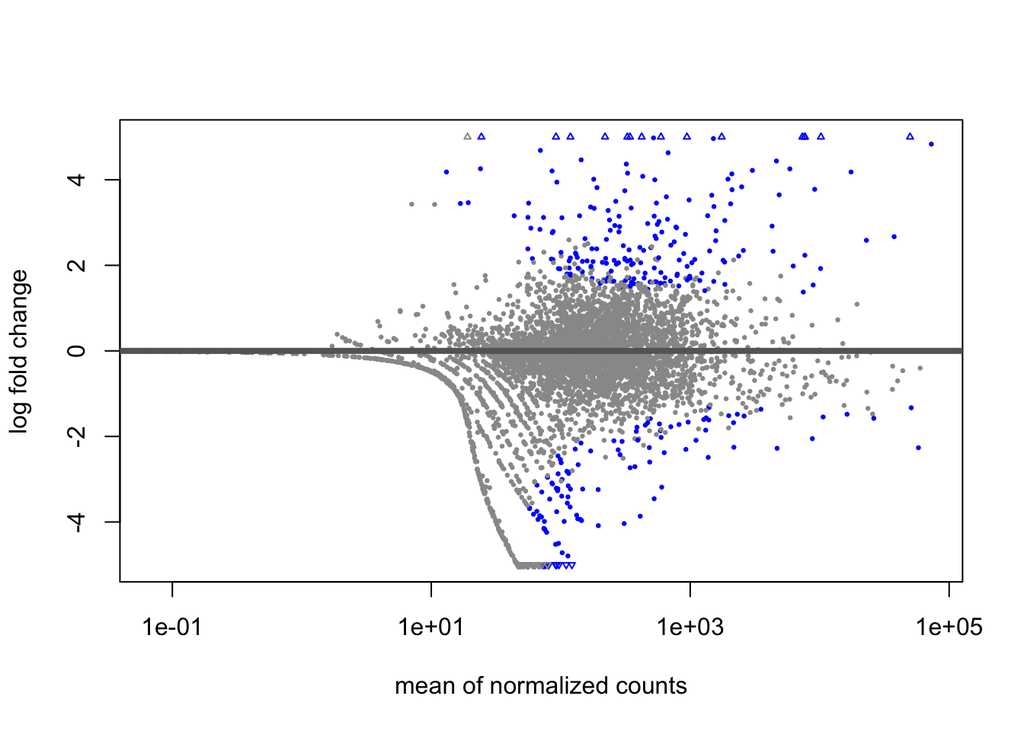

```r
plotMA(results_Ssd1bind42LFC, ylim=c(-5,5))
```

The shrinkage makes a difference for low-detected transcripts here.

### Print estimates of log2 fold-change

```r
tresults_Ssd1bind42 <- biobroom::tidy.DESeqResults(results_Ssd1bind42)

tresultsfile_42 <- "../results/Ssd1_enrichment_DeSeq2_42C.txt"

readr::write_lines(c("# Ssd1_enrichment_DeSeq2_42C.txt",
                     "# Analysis of Ssd1 enrichment at 42C, output from deseq2_Ssd1_CRAC_vs_RNAseq.Rmd",
                     "# This table is the result of biobroom::tidy applied to DeSeq2 results, then ordered by descending log2-fold change",
                     "# Edward.Wallace@ed.ac.uk, 6 Feb 2021",
                     "# "),
                   tresultsfile_42)

tresults_Ssd1bind42 %>%
  dplyr::arrange(desc(estimate)) %>%
  readr::write_tsv(tresultsfile_42, col_names = TRUE, append = TRUE)

enriched_Ssd1bind42 <-
  dplyr::filter(tresults_Ssd1bind42, estimate > 1, p.adjusted < 0.05) %>%
  dplyr::arrange(desc(estimate))

enriched_Ssd1bind42
```

```
## # A tibble: 139 x 7
##    gene      baseMean estimate stderror statistic   p.value p.adjusted
##    <chr>        <dbl>    <dbl>    <dbl>     <dbl>     <dbl>      <dbl>
##  1 YKR041W     7702.     10.8     0.538     18.2  6.41e- 74  3.92e- 71
##  2 YLR154W-C    594.      8.78    0.662     11.7  7.40e- 32  1.57e- 29
##  3 YBR040W      119.      8.01    0.541     13.0  2.03e- 38  5.51e- 36
##  4 YBL043W      343.      6.99    0.406     14.7  3.47e- 49  1.13e- 46
##  5 YNL066W    10227.      6.76    0.200     28.9  4.53e-183  2.21e-179
##  6 YDR449C      943.      6.67    0.282     20.1  3.53e- 90  3.45e- 87
##  7 YJL116C     1751.      6.65    0.312     18.1  2.84e- 73  1.54e- 70
##  8 YIL123W     7625.      6.23    0.220     23.7  2.16e-124  5.28e-121
##  9 YBR301W       24.4     5.91    1.13       4.33 1.50e-  5  7.21e-  4
## 10 YLR081W      327.      5.73    0.527      8.97 3.05e- 19  3.92e- 17
## # … with 129 more rows
```

```r
readr::write_lines(enriched_Ssd1bind42$gene,
                   "../results/Ssd1_enrichment_DeSeq2_42C_2x_padj0p05_genesonly.txt")

depleted_Ssd1bind42 <-
  dplyr::filter(tresults_Ssd1bind42, estimate < -1, p.adjusted < 0.05) %>%
  dplyr::arrange(estimate)

depleted_Ssd1bind42
```

```
## # A tibble: 77 x 7
##    gene    baseMean estimate stderror statistic   p.value p.adjusted
##    <chr>      <dbl>    <dbl>    <dbl>     <dbl>     <dbl>      <dbl>
##  1 YGL196W    122.     -7.02     1.50     -4.03 0.0000559    0.00249
##  2 YLR197W    110.     -6.88     1.52     -3.87 0.000108     0.00445
##  3 YHR012W     96.7    -6.69     1.51     -3.78 0.000158     0.00630
##  4 YKL128C     92.8    -6.63     1.51     -3.73 0.000188     0.00729
##  5 YNL288W     91.5    -6.61     1.51     -3.72 0.000201     0.00773
##  6 YDR211W     80.8    -6.43     1.52     -3.57 0.000353     0.0121
##  7 YAR015W     80.0    -6.42     1.53     -3.55 0.000385     0.0128
##  8 YKL209C     79.2    -6.40     1.61     -3.36 0.000778     0.0217
##  9 YGL130W     76.4    -6.35     1.52     -3.52 0.000438     0.0140
## 10 YDL212W     74.5    -6.31     1.52     -3.49 0.000480     0.0150
## # … with 67 more rows
```

### Make Volcano plot

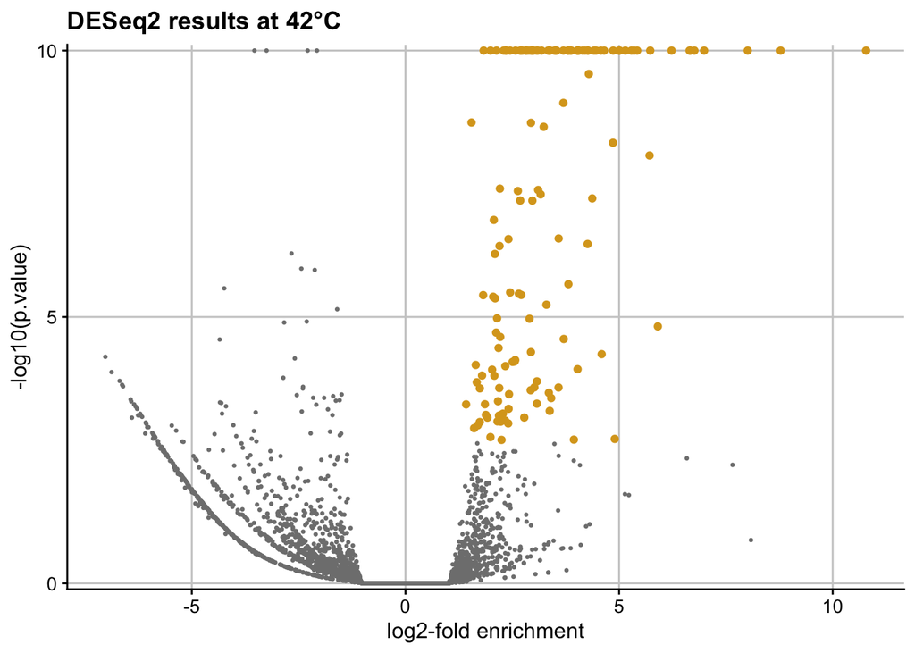

```r
volcano_42C <-
  ggplot(data = tresults_Ssd1bind42,
         aes(x=estimate,y=-log10(p.value))) +
  geom_point(colour = "grey50",size = 0.5) +
  geom_point(data = enriched_Ssd1bind42,
             colour = "goldenrod") +
  scale_y_continuous(breaks = c(0,5,10),
                     limits = c(0,10),
                     expand = c(0.01,0.01),
                     oob = scales::squish) +
  labs(x = "log2-fold enrichment",
       title = "DESeq2 results at 42°C")

volcano_42C
```

## Compare results at 30C and 42C

### Check correlations in fold change (binding enrichment) between 30C and 42C data.

```r
tresults_joined <- dplyr::full_join(tresults_Ssd1bind30, tresults_Ssd1bind42,
                                    by = "gene", suffix = c(".30",".42"))

cor(tresults_joined$estimate.30, tresults_joined$estimate.42,
    use = "pairwise.complete.obs")
```

```
## [1] 0.363176
```

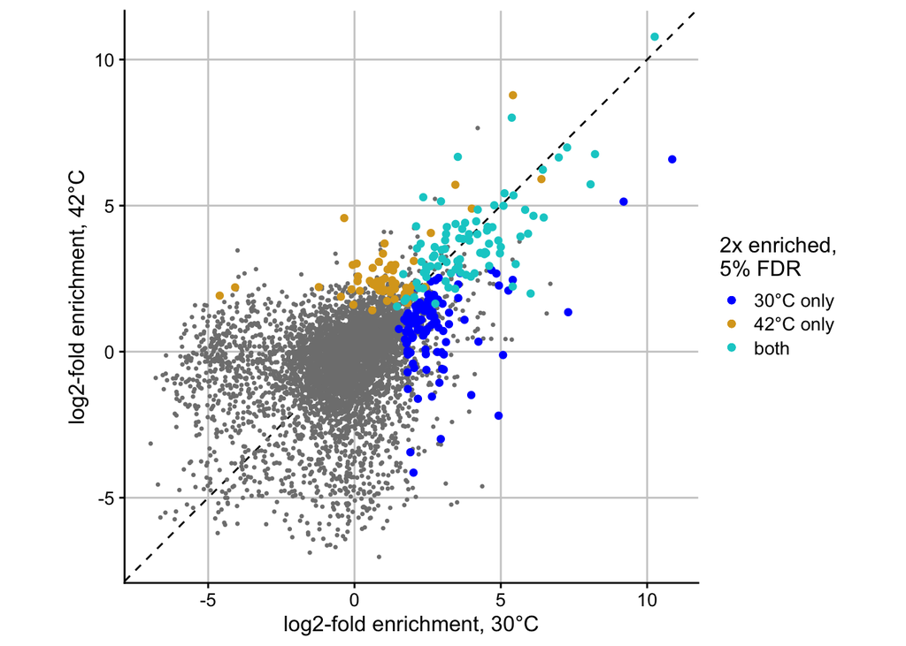

```r
enriched_intersect   <- intersect(enriched_Ssd1bind30$gene, enriched_Ssd1bind42$gene)
enriched_30Conly <- setdiff(enriched_Ssd1bind30$gene, enriched_Ssd1bind42$gene)
enriched_42Conly <- setdiff(enriched_Ssd1bind42$gene, enriched_Ssd1bind30$gene)

plot_compare_foldchange3042 <-
  ggplot(data = tresults_joined, aes(x = estimate.30, y = estimate.42)) +
  geom_abline(slope = 1, intercept = 0, size = 0.5, linetype = "dashed") +
  geom_point(colour = "grey50",size = 0.5) +
  geom_point(data = dplyr::filter(tresults_joined, gene %in% enriched_30Conly),
             aes(colour = "30°C only")) +
  geom_point(data = dplyr::filter(tresults_joined, gene %in% enriched_42Conly),
             aes(colour = "42°C only")) +
  geom_point(data = dplyr::filter(tresults_joined, gene %in% enriched_intersect),
             aes(colour = "both")) +
  coord_equal() +
  scale_colour_manual("2x enriched,\n5% FDR",
                      values = c("30°C only" = "blue",
                                 "42°C only" = "goldenrod",
                                 "both" = "cyan3")) +
  labs(x = "log2-fold enrichment, 30°C",y = "log2-fold enrichment, 42°C")

plot_compare_foldchange3042
```

Correlations overall are not great, reflecting low depth of sequencing.

### Restricting to well-detected genes improves correlation in binding enrichment

If we restrict to abundant genes (roughly above median value) then correlations are high. So lack of correlation is driven by low coverage.

```r
tresults_joined_basemean150 <-
  dplyr::filter(tresults_joined, baseMean.30 > 150, baseMean.42 > 150)

cor(tresults_joined_basemean150$estimate.30, tresults_joined_basemean150$estimate.42,
    use = "pairwise.complete.obs")
```

```
## [1] 0.6666664
```

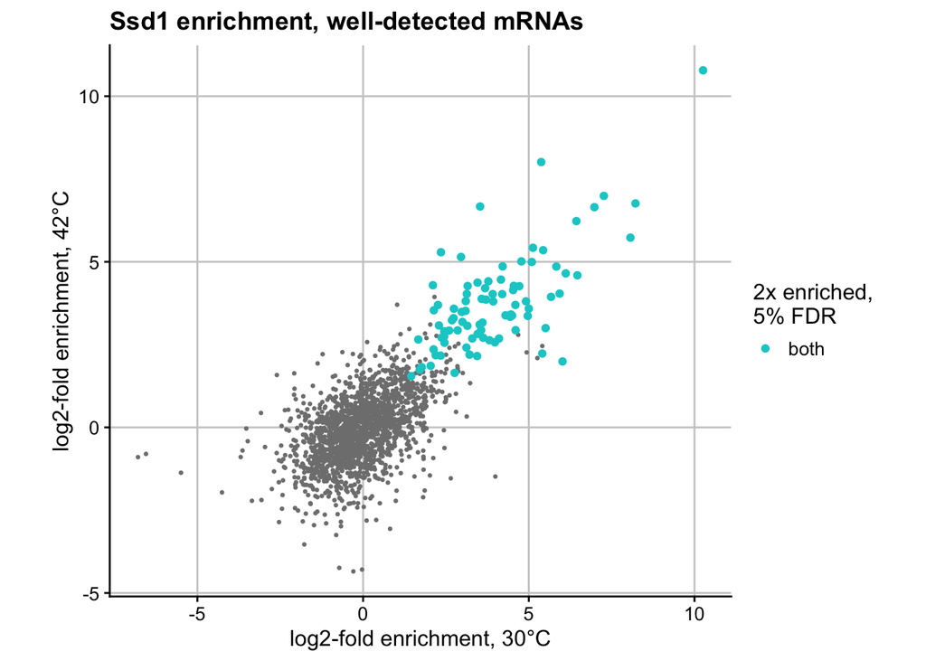

```r
ggplot(data = tresults_joined_basemean150, aes(x = estimate.30, y = estimate.42)) +
  geom_point(colour = "grey50",size = 0.5) +
  geom_point(data = dplyr::filter(tresults_joined, gene %in% enriched_intersect),
             aes(colour = "both")) +
  scale_colour_manual("2x enriched,\n5% FDR",
                      values = c("30C only" = "blue",
                                 "42C only" = "goldenrod",
                                 "both" = "cyan3")) +
  coord_equal() +
  labs(x = "log2-fold enrichment, 30°C",y = "log2-fold enrichment, 42°C",
       title = "Ssd1 enrichment, well-detected mRNAs")
```

### Compare enriched genelists at the two temperatures

Lists of enriched genes can differ between conditions because the enrichment “really” changes, or because the coverage changes and the results cross the noise threshold.

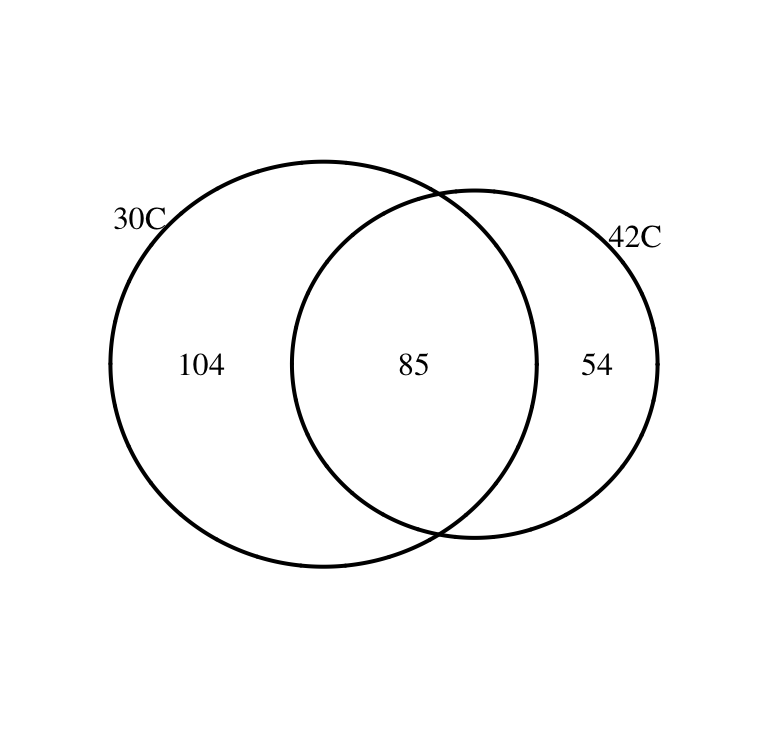

```r
library(VennDiagram)
venn <- function(...) {
    venn.diagram(x=list(...),filename=NULL,margin=0.1) %>% grid.draw
}
venn("30C"=enriched_Ssd1bind30$gene,
     "42C"=enriched_Ssd1bind42$gene)
```

### Enriched at both temperatures

```r
tresults_joined %>%
  dplyr::filter(gene %in% enriched_Ssd1bind30$gene, gene %in% enriched_Ssd1bind42$gene) %>%
  dplyr::select(gene, estimate.30, estimate.42, baseMean.30, baseMean.42) %>%
  dplyr::arrange(desc(estimate.30)) %>%
  print(n = 50)
```

```
## # A tibble: 85 x 5
##    gene      estimate.30 estimate.42 baseMean.30 baseMean.42
##    <chr>           <dbl>       <dbl>       <dbl>       <dbl>
##  1 YKR041W         10.3        10.8       9166.       7702.
##  2 YNL066W          8.22        6.76     76122.      10227.
##  3 YLR081W          8.07        5.73       374.        327.
##  4 YBL043W          7.27        6.99       382.        343.
##  5 YJL116C          6.98        6.65      1295.       1751.
##  6 YNR072W          6.47        4.59        34.4        24.0
##  7 YIL123W          6.44        6.23     33659.       7625.
##  8 YDR525W-A        6.12        4.65       721.        675.
##  9 YML054C          6.02        1.99       676.        947.
## 10 YGR041W          5.93        4.04      4520.        533.
## 11 YIR013C          5.83        4.86        49.1        69.6
## 12 YHL046C          5.67        3.94        29.2        19.3
```

[output cut: 39 more lines]

### What are the outliers? Genes enriched at 30C, not at 42C?

```r
tresults_joined %>%
  dplyr::filter(gene %in% enriched_Ssd1bind30$gene, ! gene %in% enriched_Ssd1bind42$gene) %>%
  dplyr::select(gene, estimate.30, estimate.42, baseMean.30, baseMean.42) %>%
  dplyr::arrange(desc(estimate.30)) %>%
  print(n = 40)
```

```
## # A tibble: 104 x 5
##    gene      estimate.30 estimate.42 baseMean.30 baseMean.42
##    <chr>           <dbl>       <dbl>       <dbl>       <dbl>
##  1 YLR308W         10.9       6.59         23.2       19.1
##  2 YHR079C-A        9.20      5.14         68.1       10.6
##  3 YLR013W          7.30      1.35          7.17       0.367
##  4 YHR143W          5.41      2.46      23656.      2165.
##  5 YGL096W          5.26      2.09        481.       255.
##  6 YLR307W          5.08     -0.114        38.6       19.4
##  7 YMR316W          4.94      2.26        395.       259.
##  8 YMR323W          4.92     -2.19         20.3       23.7
##  9 YMR081C          4.85      2.68         63.0       76.0
## 10 YHR167W          4.68      2.80        709.       153.
## 11 YIL060W          4.23      0.343        30.2        9.38
## 12 YGR043C          3.99     -1.48        190.      1214.
```

[output cut: 29 more lines]

### What are the outliers? Genes enriched at 42C, not at 30C?

```r
tresults_joined %>%
  dplyr::filter(!gene %in% enriched_Ssd1bind30$gene, gene %in% enriched_Ssd1bind42$gene) %>%
  dplyr::select(gene, estimate.30, estimate.42, baseMean.30, baseMean.42) %>%
  dplyr::arrange(desc(estimate.42)) %>%
  print(n = 40)
```

```
## # A tibble: 54 x 5
##    gene      estimate.30 estimate.42 baseMean.30 baseMean.42
##    <chr>           <dbl>       <dbl>       <dbl>       <dbl>
##  1 YLR154W-C      5.41          8.78      22.1         594.
##  2 YBR301W        6.39          5.91      43.7          24.4
##  3 YOR298W        3.45          5.71      58.6          91.9
##  4 YLR341W        4.01          4.90      11.4          13.1
##  5 YHR124W       -0.351         4.57       2.06        144.
##  6 YBR240C        2.61          4.06      37.5         180.
##  7 YDR492W        1.03          3.70     211.          266.
##  8 YOL047C        0.973         3.36       0.821        55.8
##  9 YDR309C        2.03          3.11     810.          573.
## 10 YIR041W        0.833         3.08       0.905        58.8
## 11 YML113W        0.0735        3.02      70.5          69.1
## 12 YPR138C        1.39          2.97     192.          557.
```

[output cut: 29 more lines]

## Print supplementary figure with volcano plots and correlations

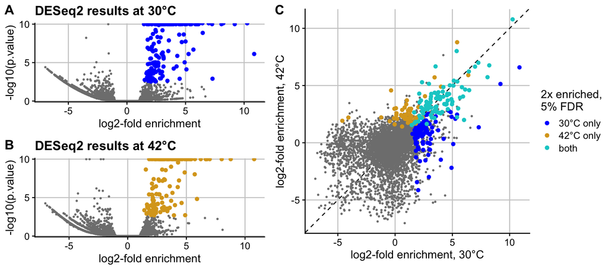

```r
plot_grid(plot_grid(volcano_30C, volcano_42C, ncol = 1, labels = c("A","B")),
          plot_compare_foldchange3042,
          ncol = 2, rel_widths = c(4,5), labels = c("","C"))
```

```r
ggsave("../figure_out/deseq2_Ssd1_CRAC_enrichment_suppfigure.png",
       width = 9, height = 4)
```

Ssd1 enrichment, results of DESeq2 analysis comparing Ssd1-bound RNA (CRAC) with poly(A)-RNA-seq. A, Volcano plot comparing log2-fold change with p value for every mRNA measured at 30°C Enriched genes with over 2x enrichment at 5% FDR are highlighted; p values below 10^-10 are squished for display. B, Volcano plot at 42°C. C, Comparison of Ssd1 log2-fold enrichment at 30°C and 42°C.